# CryptoCourseDataAnalysis

Joy Machuka

8/27/2021

Defining the question

A Kenyan entrepreneur has created an online cryptography course and would want to advertise it on her blog. She currently targets audiences originating from various countries. In the past, she ran ads to advertise a related course on the same blog and collected data in the process. She would now like to employ your services as a Data Science Consultant to help her identify which individuals are most likely to click on her ads.

Metric of success

Our analysis will be considered successful if we are able to analyze the data and get the most likely to take the course statistics.

Experimental Design

Data preparation Data Cleaning Univariate Analysis Bivariate Analysis

```r
#load dataset
crypto <- read.csv('http://bit.ly/IPAdvertisingData')
head(crypto)
```

```
##   Daily.Time.Spent.on.Site Age Area.Income Daily.Internet.Usage
## 1                    68.95  35    61833.90               256.09
## 2                    80.23  31    68441.85               193.77
## 3                    69.47  26    59785.94               236.50
## 4                    74.15  29    54806.18               245.89
## 5                    68.37  35    73889.99               225.58
## 6                    59.99  23    59761.56               226.74
##                           Ad.Topic.Line           City Male    Country
## 1    Cloned 5thgeneration orchestration    Wrightburgh    0    Tunisia
## 2    Monitored national standardization      West Jodi    1      Nauru
## 3      Organic bottom-line service-desk       Davidton    0 San Marino
## 4 Triple-buffered reciprocal time-frame West Terrifurt    1      Italy
## 5         Robust logistical utilization   South Manuel    0    Iceland
## 6       Sharable client-driven software      Jamieberg    1     Norway
##             Timestamp Clicked.on.Ad
## 1 2016-03-27 00:53:11             0
## 2 2016-04-04 01:39:02             0
## 3 2016-03-13 20:35:42             0
## 4 2016-01-10 02:31:19             0
## 5 2016-06-03 03:36:18             0
## 6 2016-05-19 14:30:17             0
```

```r
#preview the dataset
View(crypto)
```

```r
#viewing first 6 rows
head(crypto, 6)
```

```
##   Daily.Time.Spent.on.Site Age Area.Income Daily.Internet.Usage
## 1                    68.95  35    61833.90               256.09
## 2                    80.23  31    68441.85               193.77
## 3                    69.47  26    59785.94               236.50
## 4                    74.15  29    54806.18               245.89
## 5                    68.37  35    73889.99               225.58
## 6                    59.99  23    59761.56               226.74
##                           Ad.Topic.Line           City Male    Country
## 1    Cloned 5thgeneration orchestration    Wrightburgh    0    Tunisia
## 2    Monitored national standardization      West Jodi    1      Nauru
## 3      Organic bottom-line service-desk       Davidton    0 San Marino
## 4 Triple-buffered reciprocal time-frame West Terrifurt    1      Italy
## 5         Robust logistical utilization   South Manuel    0    Iceland
## 6       Sharable client-driven software      Jamieberg    1     Norway
##             Timestamp Clicked.on.Ad
## 1 2016-03-27 00:53:11             0
## 2 2016-04-04 01:39:02             0
## 3 2016-03-13 20:35:42             0
## 4 2016-01-10 02:31:19             0
## 5 2016-06-03 03:36:18             0
## 6 2016-05-19 14:30:17             0
```

```r
#check the shape of dataset
dim(crypto)
```

```
## [1] 1000   10
```

```r
#checking the class of our dataset
class(crypto)
```

```
## [1] "data.frame"
```

```r
#checking column names
names(crypto)
```

```
##  [1] "Daily.Time.Spent.on.Site" "Age"
##  [3] "Area.Income"              "Daily.Internet.Usage"
##  [5] "Ad.Topic.Line"            "City"
##  [7] "Male"                     "Country"
##  [9] "Timestamp"                "Clicked.on.Ad"
```

```r
#checking datas types of variables
str(crypto)
```

```
## 'data.frame':    1000 obs. of  10 variables:
##  $ Daily.Time.Spent.on.Site: num  69 80.2 69.5 74.2 68.4 ...
##  $ Age                     : int  35 31 26 29 35 23 33 48 30 20 ...
##  $ Area.Income             : num  61834 68442 59786 54806 73890 ...
##  $ Daily.Internet.Usage    : num  256 194 236 246 226 ...
##  $ Ad.Topic.Line           : chr  "Cloned 5thgeneration orchestration" "Monitored national standardization" "Organic bottom-line service-desk" "Triple-buffered reciprocal time-frame" ...
##  $ City                    : chr  "Wrightburgh" "West Jodi" "Davidton" "West Terrifurt" ...
##  $ Male                    : int  0 1 0 1 0 1 0 1 1 1 ...
##  $ Country                 : chr  "Tunisia" "Nauru" "San Marino" "Italy" ...
##  $ Timestamp               : chr  "2016-03-27 00:53:11" "2016-04-04 01:39:02" "2016-03-13 20:35:42" "2016-01-10 02:31:19" ...
##  $ Clicked.on.Ad           : int  0 0 0 0 0 0 0 1 0 0 ...
```

```r
#searching for information about dataset
??crypto
```

```
## starting httpd help server ... done
```

Data Cleaning

```r
#checking for null values per column
colSums(is.na(crypto))
```

```
## Daily.Time.Spent.on.Site                      Age              Area.Income
##                        0                        0                        0
##     Daily.Internet.Usage            Ad.Topic.Line                     City
##                        0                        0                        0
##                     Male                  Country                Timestamp
##                        0                        0                        0
##            Clicked.on.Ad
##                        0
```

```r
#checking for duplicates
duplicated_rows <- crypto[duplicated(crypto),]
duplicated_rows
```

```
##  [1] Daily.Time.Spent.on.Site Age                      Area.Income
##  [4] Daily.Internet.Usage     Ad.Topic.Line            City
##  [7] Male                     Country                  Timestamp
## [10] Clicked.on.Ad
## <0 rows> (or 0-length row.names)
```

There aren’t any duplicated rows and missing data from our dataset as seen above.

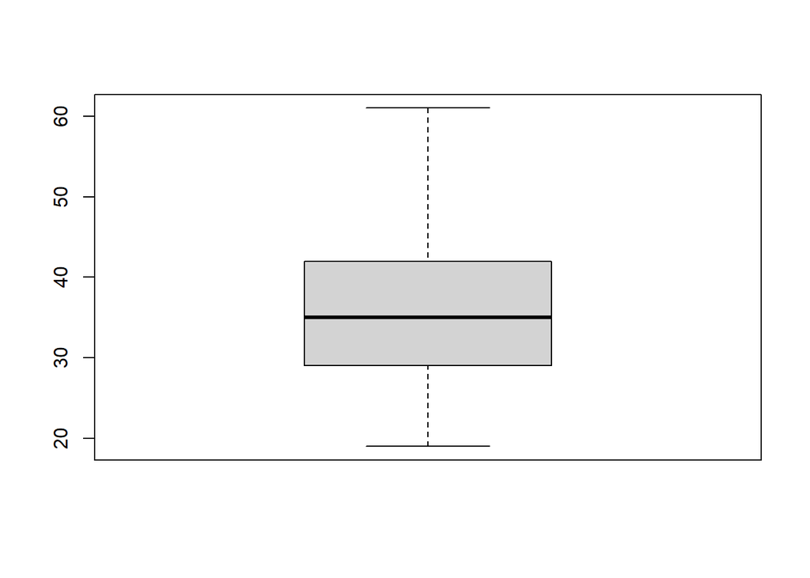

```r
#checking for outliers
boxplot(crypto$Age)
```

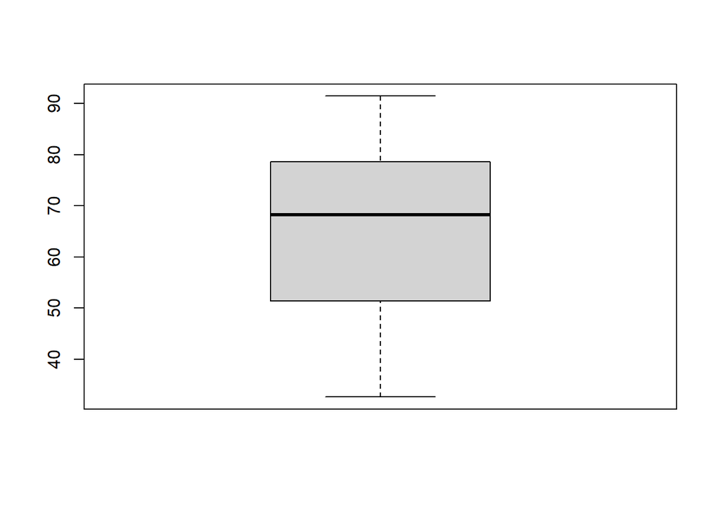

```r
boxplot(crypto$Daily.Time.Spent.on.Site)
```

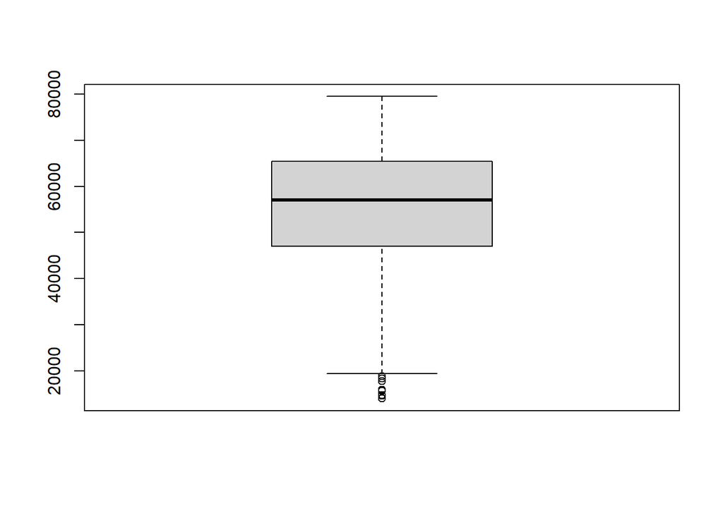

```r
boxplot(crypto$Area.Income)
```

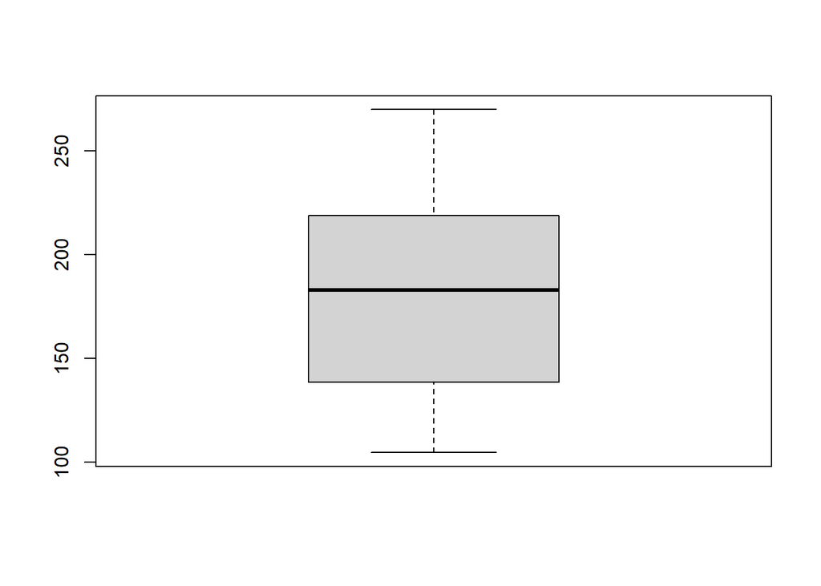

```r
boxplot(crypto$Daily.Internet.Usage)
```

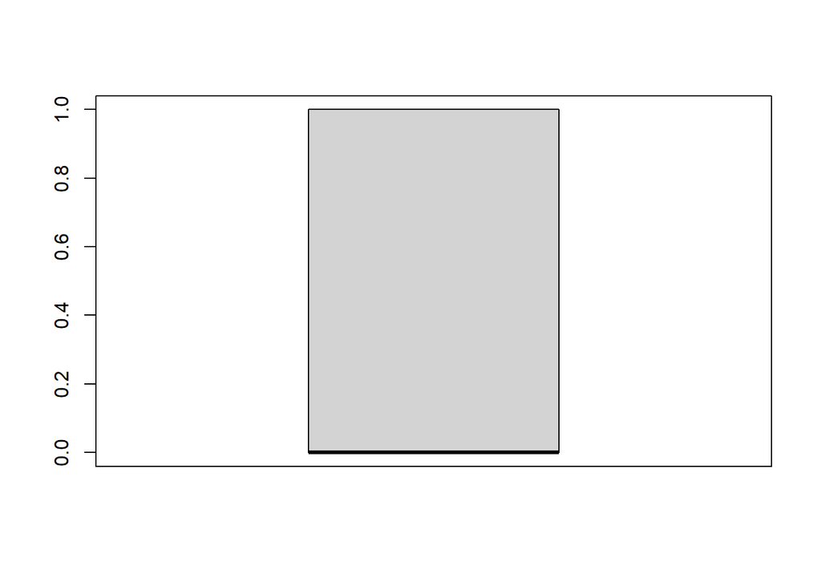

```r
boxplot(crypto$Male)
```

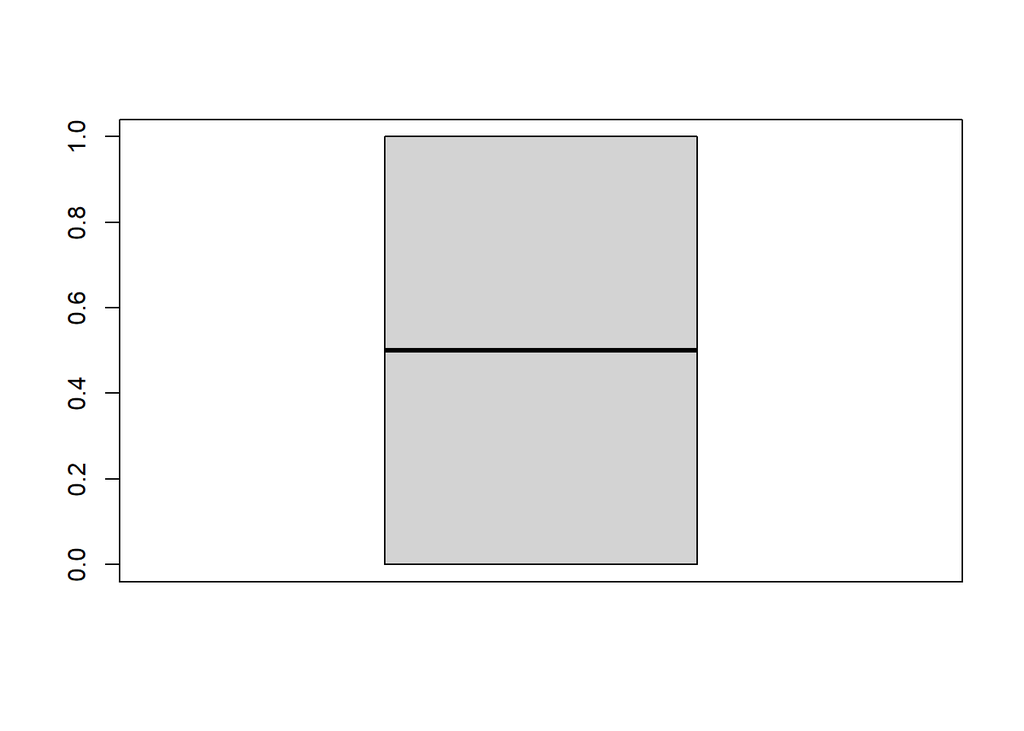

```r
boxplot(crypto$Clicked.on.Ad)
```

```r
# boxplot(crypto$Ad.Topic.Line)
# boxplot(crypto$City)
# boxplot(crypto$Country)
# boxplot(crypto$Timestamp)
```

```r
# par(mfrow = c(2, 2))  # Set up a 2 x 2 plotting space
#
# # Create the loop.vector (all the columns)
# loop.vector <- 1:10
#
# for (i in loop.vector) { # Loop over loop.vector
# # store data in column.i as x
#   x <- crypto[,i]
# # Plot boxplot of x
#   boxplot(x, main = paste("plot", i),
#        xlim = c(0, 2))
# }
```

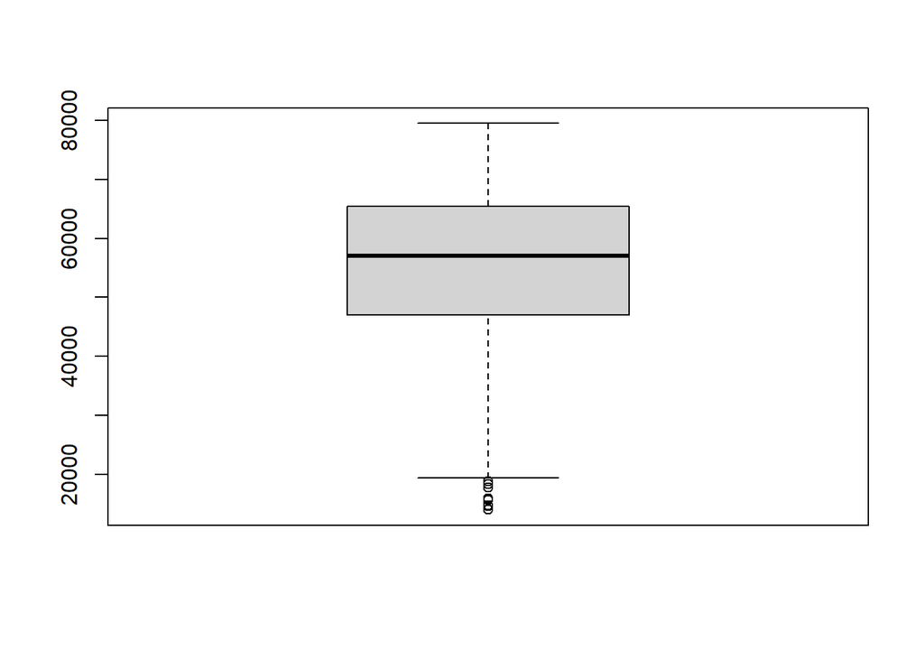

```r
# Viewing the outliers in the Area.Income column since it is the only column with outliers
boxplot(crypto$Area.Income)
```

```r
#viewing the outlier rows
boxplot.stats(crypto$Area.Income)$out
```

```
## [1] 17709.98 18819.34 15598.29 15879.10 14548.06 13996.50 14775.50 18368.57
```

```r
quantile(crypto$Area.Income)
```

```
##       0%      25%      50%      75%     100%
## 13996.50 47031.80 57012.30 65470.64 79484.80
```

## #We decided to leave our outliers since they seemed viable and helpful to our analysis after looking at the quantile distribution

## Univariate Analysis

```r
#summary statistics of all the columns
summary(crypto)
```

```
##  Daily.Time.Spent.on.Site      Age         Area.Income    Daily.Internet.Usage
##  Min.   :32.60            Min.   :19.00   Min.   :13996   Min.   :104.8
##  1st Qu.:51.36            1st Qu.:29.00   1st Qu.:47032   1st Qu.:138.8
##  Median :68.22            Median :35.00   Median :57012   Median :183.1
##  Mean   :65.00            Mean   :36.01   Mean   :55000   Mean   :180.0
##  3rd Qu.:78.55            3rd Qu.:42.00   3rd Qu.:65471   3rd Qu.:218.8
##  Max.   :91.43            Max.   :61.00   Max.   :79485   Max.   :270.0
##  Ad.Topic.Line          City                Male         Country
##  Length:1000        Length:1000        Min.   :0.000   Length:1000
##  Class :character   Class :character   1st Qu.:0.000   Class :character
##  Mode  :character   Mode  :character   Median :0.000   Mode  :character
##                                        Mean   :0.481
##                                        3rd Qu.:1.000
##                                        Max.   :1.000
##   Timestamp         Clicked.on.Ad
##  Length:1000        Min.   :0.0
##  Class :character   1st Qu.:0.0
##  Mode  :character   Median :0.5
##                     Mean   :0.5
##                     3rd Qu.:1.0
##                     Max.   :1.0
```

```r
num = crypto[,c(1,2,3,4,7,10)]
summary(num)
```

```
##  Daily.Time.Spent.on.Site      Age         Area.Income    Daily.Internet.Usage
##  Min.   :32.60            Min.   :19.00   Min.   :13996   Min.   :104.8
##  1st Qu.:51.36            1st Qu.:29.00   1st Qu.:47032   1st Qu.:138.8
##  Median :68.22            Median :35.00   Median :57012   Median :183.1
##  Mean   :65.00            Mean   :36.01   Mean   :55000   Mean   :180.0
##  3rd Qu.:78.55            3rd Qu.:42.00   3rd Qu.:65471   3rd Qu.:218.8
##  Max.   :91.43            Max.   :61.00   Max.   :79485   Max.   :270.0
##       Male       Clicked.on.Ad
##  Min.   :0.000   Min.   :0.0
##  1st Qu.:0.000   1st Qu.:0.0
##  Median :0.000   Median :0.5
##  Mean   :0.481   Mean   :0.5
##  3rd Qu.:1.000   3rd Qu.:1.0
##  Max.   :1.000   Max.   :1.0
```

```r
#Mean
mean(crypto$Daily.Time.Spent.on.Site)
```

```
## [1] 65.0002
```

```r
mean(crypto$Age)
```

```
## [1] 36.009
```

```r
mean(crypto$Area.Income)
```

```
## [1] 55000
```

```r
mean(crypto$Daily.Internet.Usage)
```

```
## [1] 180.0001
```

```r
mean(crypto$Male)
```

```
## [1] 0.481
```

```r
mean(crypto$Clicked.on.Ad)
```

```
## [1] 0.5
```

```r
# Median
median(crypto$Daily.Time.Spent.on.Site)
```

```
## [1] 68.215
```

```r
median(crypto$Age)
```

```
## [1] 35
```

```r
median(crypto$Area.Income)
```

```
## [1] 57012.3
```

```r
median(crypto$Daily.Internet.Usage)
```

```
## [1] 183.13
```

```r
median(crypto$Male)
```

```
## [1] 0
```

```r
median(crypto$Clicked.on.Ad)
```

```
## [1] 0.5
```

```r
#mode of the columns
getmode <- function(v) {
   uniqv <- unique(v)
   uniqv[which.max(tabulate(match(v, uniqv)))]
}
getmode(crypto$Daily.Time.Spent.on.Site)
```

```
## [1] 62.26
```

```r
getmode(crypto$Age)
```

```
## [1] 31
```

```r
getmode(crypto$Area.Income)
```

```
## [1] 61833.9
```

```r
getmode(crypto$Daily.Internet.Usage)
```

```
## [1] 167.22
```

```r
getmode(crypto$Male)
```

```
## [1] 0
```

```r
getmode(crypto$Clicked.on.Ad)
```

```
## [1] 0
```

```r
#Variance
var(crypto$Daily.Time.Spent.on.Site)
```

```
## [1] 251.3371
```

```r
var(crypto$Age)
```

```
## [1] 77.18611
```

```r
var(crypto$Area.Income)
```

```
## [1] 179952406
```

```r
var(crypto$Daily.Internet.Usage)
```

```
## [1] 1927.415
```

```r
var(crypto$Male)
```

```
## [1] 0.2498889
```

```r
var(crypto$Clicked.on.Ad)
```

```
## [1] 0.2502503
```

```r
# Standard Deviation
sd(crypto$Daily.Time.Spent.on.Site)
```

```
## [1] 15.85361
```

```r
sd(crypto$Age)
```

```
## [1] 8.785562
```

```r
sd(crypto$Area.Income)
```

```
## [1] 13414.63
```

```r
sd(crypto$Daily.Internet.Usage)
```

```
## [1] 43.90234
```

```r
sd(crypto$Male)
```

```
## [1] 0.4998889
```

```r
sd(crypto$Clicked.on.Ad)
```

```
## [1] 0.5002502
```

```r
#Quantiles
quantile(crypto$Daily.Time.Spent.on.Site)
```

```
##      0%     25%     50%     75%    100%
## 32.6000 51.3600 68.2150 78.5475 91.4300
```

```r
quantile(crypto$Age)
```

```
##   0%  25%  50%  75% 100%
##   19   29   35   42   61
```

```r
quantile(crypto$Area.Income)
```

```
##       0%      25%      50%      75%     100%
## 13996.50 47031.80 57012.30 65470.64 79484.80
```

```r
quantile(crypto$Daily.Internet.Usage)
```

```
##       0%      25%      50%      75%     100%
## 104.7800 138.8300 183.1300 218.7925 269.9600
```

```r
quantile(crypto$Male)
```

```
##   0%  25%  50%  75% 100%
##    0    0    0    1    1
```

```r
quantile(crypto$Clicked.on.Ad)
```

```
##   0%  25%  50%  75% 100%
##  0.0  0.0  0.5  1.0  1.0
```

```r
# par(mfrow = c(2, 5))  # Set up a 2 x 2 plotting space
#
# # Create the loop.vector (all the columns)
# loop.vector <- 1:10
#
# for (i in loop.vector) { # Loop over loop.vector
#
# # store data in column.i as x
#   x <- crypto[,i]
#
# # Plot histogram of x
#   hist(x,
#        main = paste("histogram", i),
#        xlab = "Scores",
#        xlim = c(0, 100))
# }
```

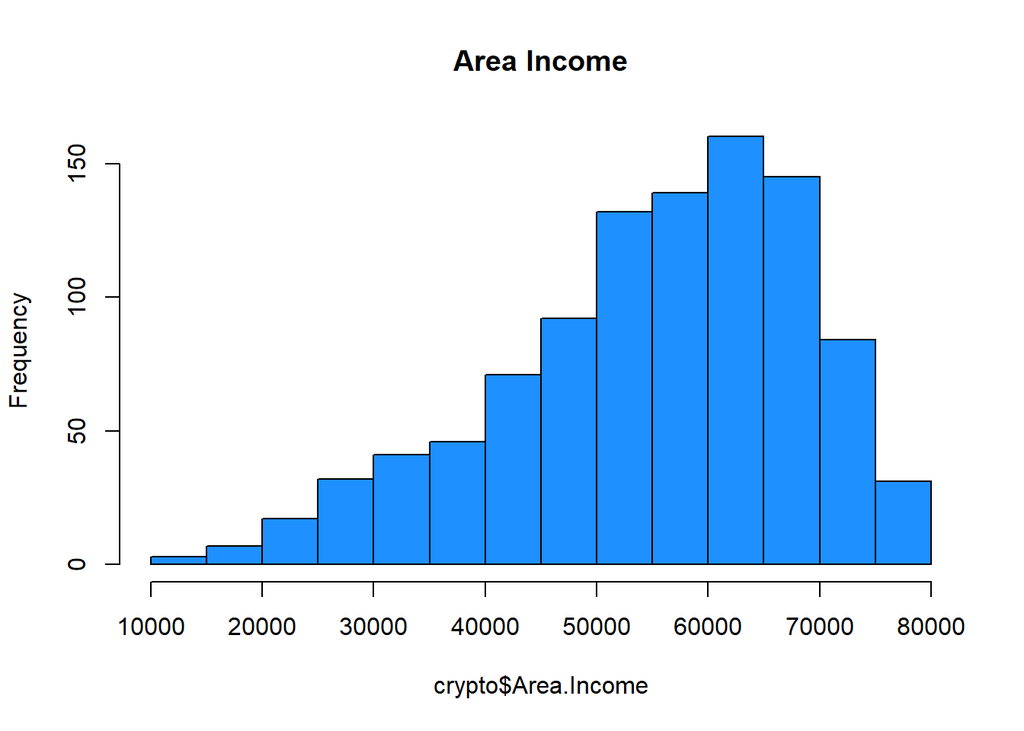

```r
hist(crypto$Area.Income, breaks = 10, main = "Area Income",col = "dodgerblue")
```

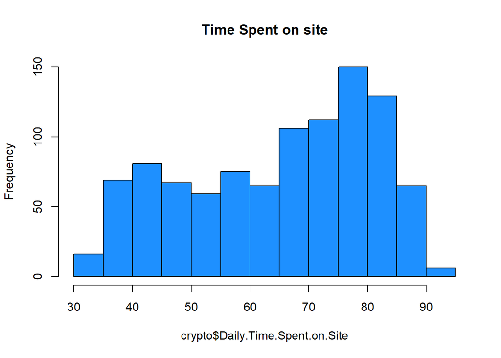

```r
hist(crypto$Daily.Time.Spent.on.Site, breaks = 10, main = "Time Spent on site",col = "dodgerblue")
```

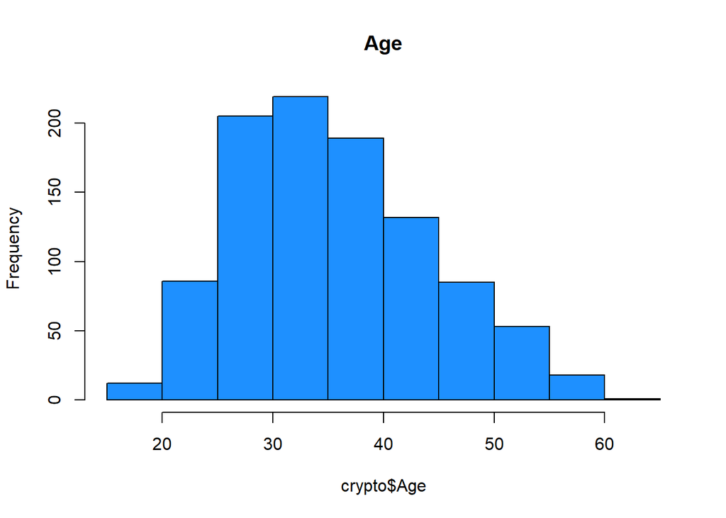

```r
hist(crypto$Age, breaks = 10, main = "Age",col = "dodgerblue")
```

```r
names(crypto)
```

```
##  [1] "Daily.Time.Spent.on.Site" "Age"
##  [3] "Area.Income"              "Daily.Internet.Usage"
##  [5] "Ad.Topic.Line"            "City"
##  [7] "Male"                     "Country"
##  [9] "Timestamp"                "Clicked.on.Ad"
```

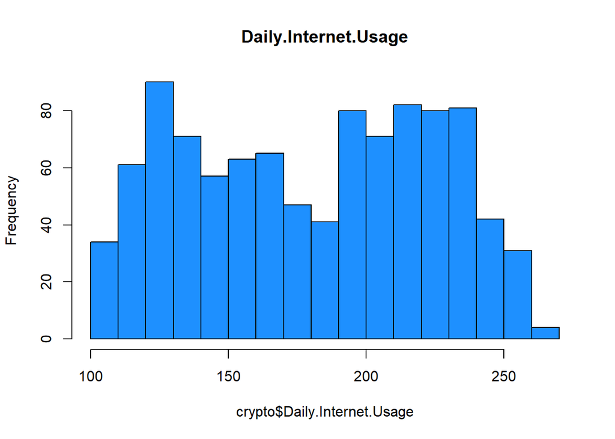

```r
hist(crypto$Daily.Internet.Usage, breaks = 20, main = "Daily.Internet.Usage",col = "dodgerblue")
```

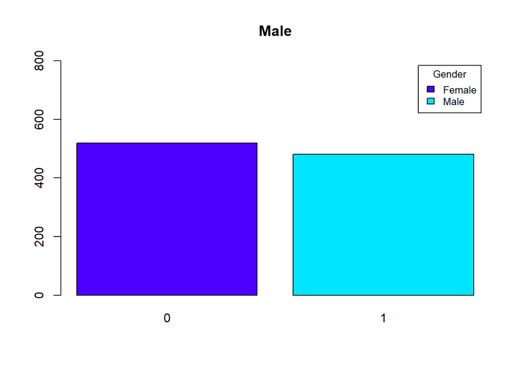

```r
male <- table(crypto$Male)
barplot(male,main = "Male",col = topo.colors(2),ylim = c(0, 800))
legend("topright",inset = .02, title="Gender",
       c("Female","Male"), fill=topo.colors(2), cex=0.8)
```

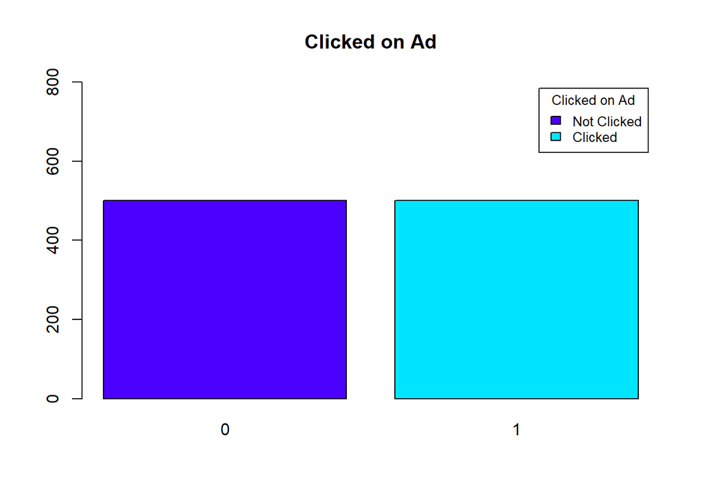

```r
clicked <- table(crypto$Clicked.on.Ad)
barplot(clicked,main = "Clicked on Ad",col = topo.colors(2), ylim = c(0,800))
legend("topright",inset = .02, title="Clicked on Ad",
       c("Not Clicked","Clicked"), fill=topo.colors(2), cex=0.8)
```

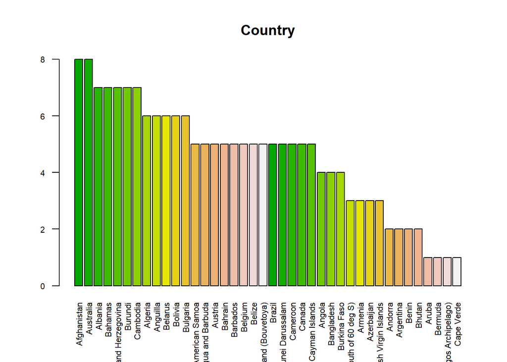

```r
par(las=2, cex.axis=0.7)
country <- table(crypto$Country)
barplot(sort(country[1:40], decreasing = TRUE), main = "Country",col = terrain.colors(20))
```

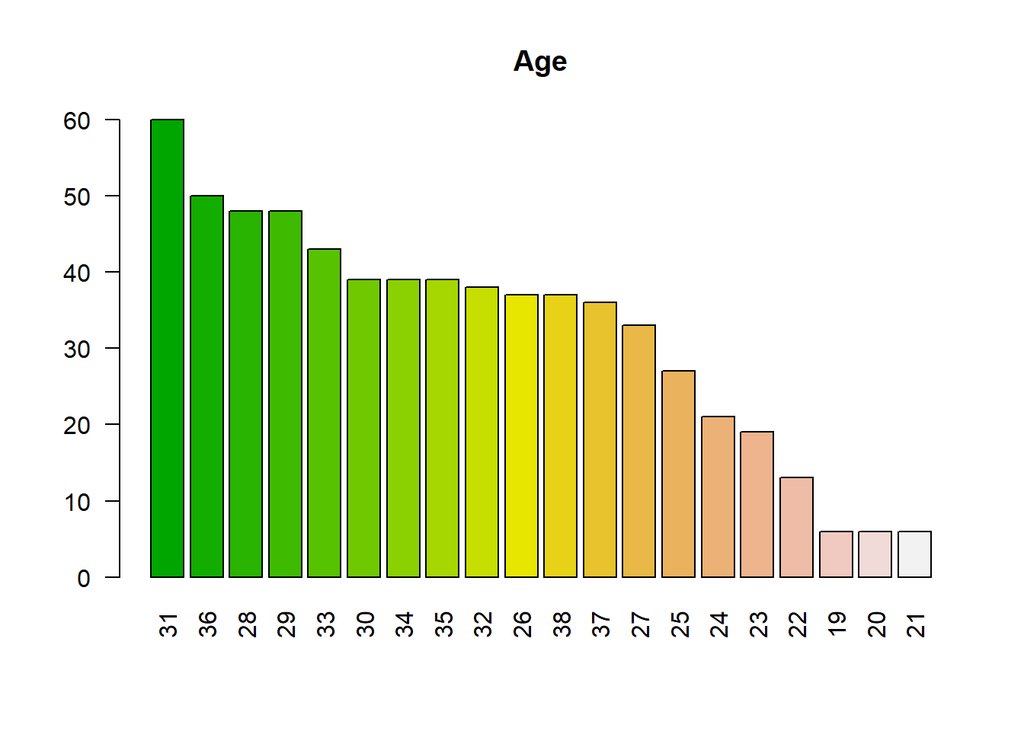

```r
par(las=2)
age <- table(crypto$Age)
barplot(sort(age[1:20], decreasing = TRUE), main = "Age",col = terrain.colors(20))
```

```r
# install.packages('dplyr')
```

```r
# install.packages('ggplot2')
```

```r
library("dplyr")
```

```r
library("ggplot2")
# group by gender/Male
by_time <- crypto %>%
  group_by(Male) %>%
  summarise(Total.Time.Spent.on.Site = sum(Daily.Time.Spent.on.Site))
by_time
```

```
## # A tibble: 2 x 2
##    Male Total.Time.Spent.on.Site
##   <int>                    <dbl>
## 1     0                   33885.
## 2     1                   31115.
```

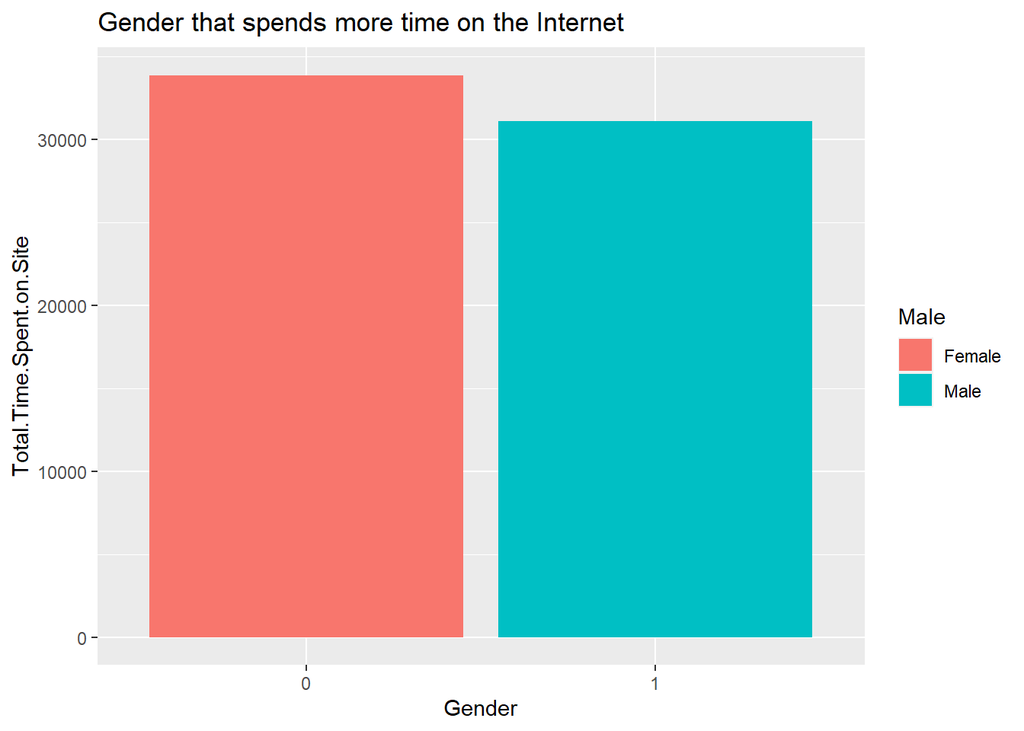

```r
p <- ggplot(by_time, aes(x = factor(Male), y = Total.Time.Spent.on.Site, fill = factor(Male)))+geom_bar(stat="identity")
p + scale_fill_discrete(name = "Male", labels = c("Female","Male"))+ labs(title="Gender that spends more time on the Internet", x="Gender")
```

```r
#separating clicked ads
clicked_ad <- crypto[crypto$Clicked.on.Ad == 1,]
```

```r
#countries with more clicked ads
country <- crypto %>% group_by(Country) %>% summarise(clicked.ad =sum(Clicked.on.Ad[Clicked.on.Ad == 1]))
```

```r
# c <- ggplot(rows, aes(x = reorder(Country,clicked.ad), y=clicked.ad)) + geom_col() +coord_flip() +  geom_bar(stat="identity", fill="dodgerblue")
# c + labs(title="Country with Highest Clicks on Ads", x="Countries", y="Clicked Ads")
```

```r
# Females that click on ads
gender <- crypto %>% group_by(Clicked.on.Ad) %>% summarise(gender = length(Male[Male == 0]))
gender
```

```
## # A tibble: 2 x 2
##   Clicked.on.Ad gender
##           <int>  <int>
## 1             0    250
## 2             1    269
```

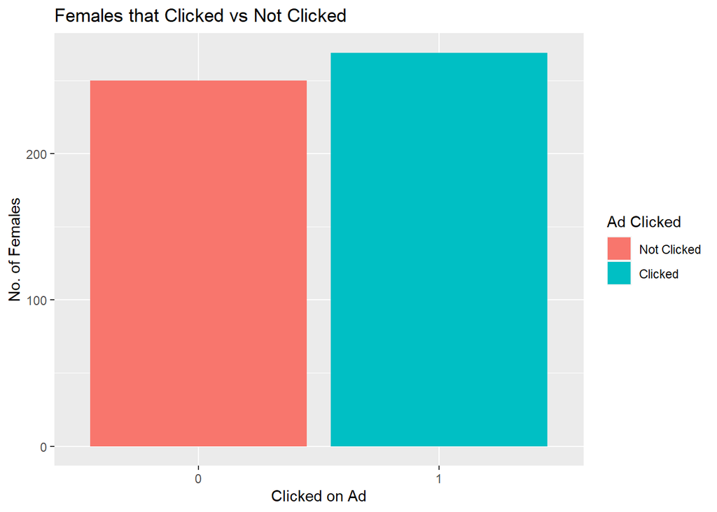

```r
females <- ggplot(gender, aes(x = factor(Clicked.on.Ad), y = gender, fill=factor(Clicked.on.Ad))) + geom_bar(stat="identity")
females + scale_fill_discrete(name = "Ad Clicked", labels = c("Not Clicked","Clicked"))+ labs(title="Females that Clicked vs Not Clicked", x="Clicked on Ad", y="No. of Females")
```

```r
# Males that clicked on ads
males <- crypto %>% group_by(Clicked.on.Ad) %>% summarise(gender = length(Male[Male == 1]))
males
```

```
## # A tibble: 2 x 2
##   Clicked.on.Ad gender
##           <int>  <int>
## 1             0    250
## 2             1    231
```

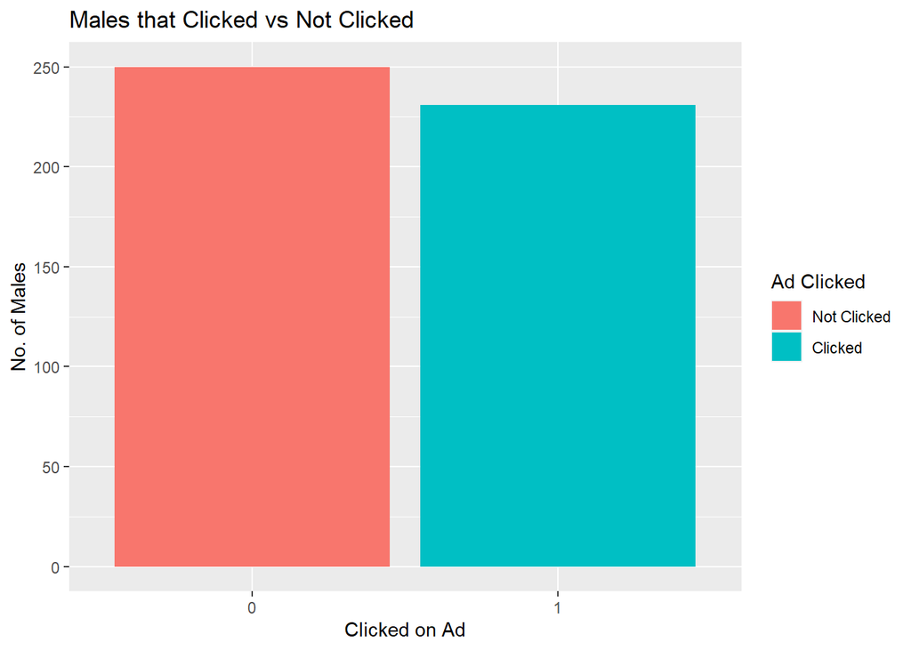

```r
males <- ggplot(males, aes(x = factor(Clicked.on.Ad), y = gender, fill=factor(Clicked.on.Ad))) + geom_bar(stat="identity")
males + scale_fill_discrete(name = "Ad Clicked", labels = c("Not Clicked","Clicked"))+ labs(title="Males that Clicked vs Not Clicked", x="Clicked on Ad", y="No. of Males")
```

Bivariate Analysis

```r
str(crypto)
```

```
## 'data.frame':    1000 obs. of  10 variables:
##  $ Daily.Time.Spent.on.Site: num  69 80.2 69.5 74.2 68.4 ...
##  $ Age                     : int  35 31 26 29 35 23 33 48 30 20 ...
##  $ Area.Income             : num  61834 68442 59786 54806 73890 ...
##  $ Daily.Internet.Usage    : num  256 194 236 246 226 ...
##  $ Ad.Topic.Line           : chr  "Cloned 5thgeneration orchestration" "Monitored national standardization" "Organic bottom-line service-desk" "Triple-buffered reciprocal time-frame" ...
##  $ City                    : chr  "Wrightburgh" "West Jodi" "Davidton" "West Terrifurt" ...
##  $ Male                    : int  0 1 0 1 0 1 0 1 1 1 ...
##  $ Country                 : chr  "Tunisia" "Nauru" "San Marino" "Italy" ...
##  $ Timestamp               : chr  "2016-03-27 00:53:11" "2016-04-04 01:39:02" "2016-03-13 20:35:42" "2016-01-10 02:31:19" ...
##  $ Clicked.on.Ad           : int  0 0 0 0 0 0 0 1 0 0 ...
```

```r
head(num,4)
```

```
##   Daily.Time.Spent.on.Site Age Area.Income Daily.Internet.Usage Male
## 1                    68.95  35    61833.90               256.09    0
## 2                    80.23  31    68441.85               193.77    1
## 3                    69.47  26    59785.94               236.50    0
## 4                    74.15  29    54806.18               245.89    1
##   Clicked.on.Ad
## 1             0
## 2             0
## 3             0
## 4             0
```

```r
# Covariance
covariance = cov(num)
View(round(covariance,2))
```

```r
# Correlation Matrix
correlation_matrix = cor(num)
View(round(correlation_matrix,2))
```

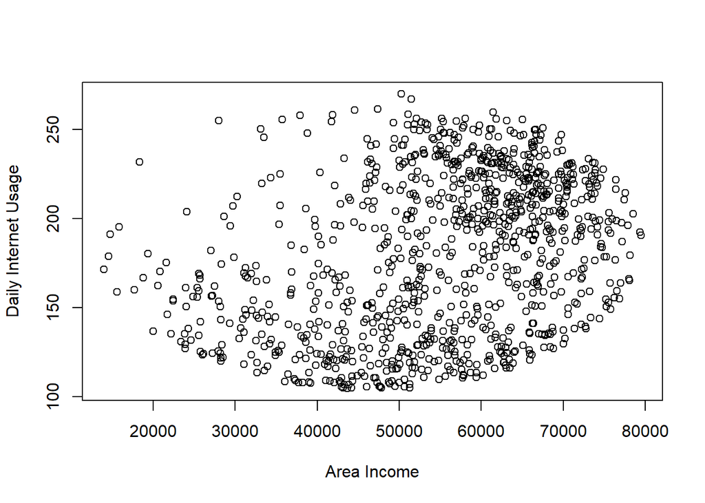

```r
# Scatter Plot
area.income <- crypto$Area.Income
internet.usage <- crypto$Daily.Internet.Usage
time.spent <- crypto$Daily.Time.Spent.on.Site

plot(area.income, internet.usage, xlab="Area Income",ylab = "Daily Internet Usage")
```

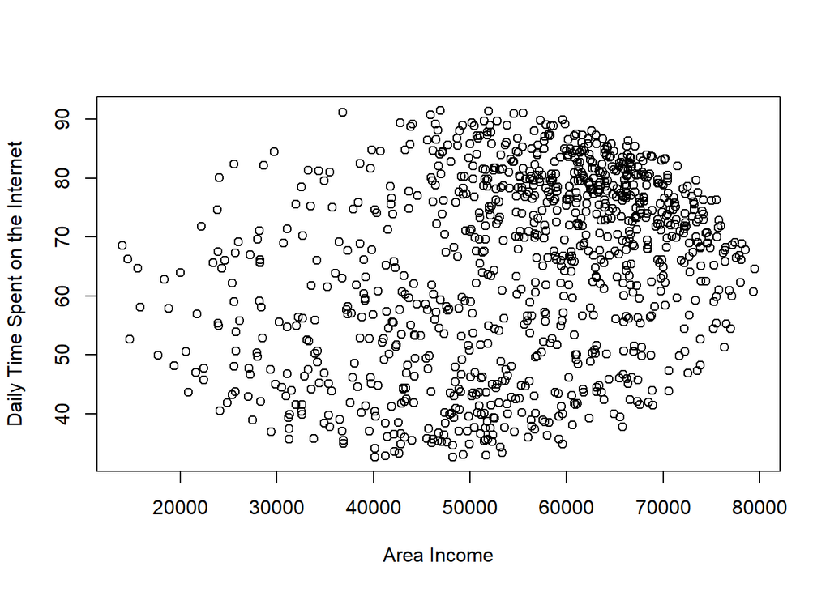

```r
plot(area.income,time.spent,xlab = "Area Income",ylab = "Daily Time Spent on the Internet")
```

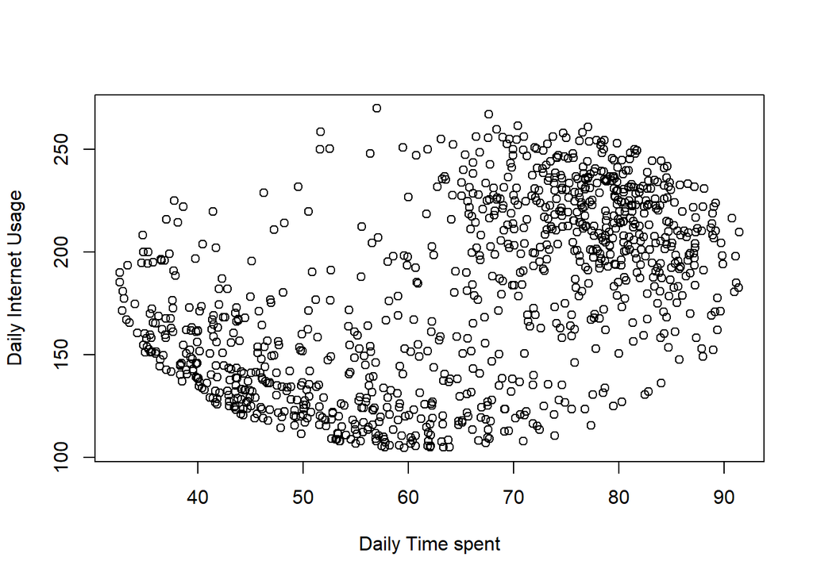

```r
plot(time.spent,internet.usage, xlab="Daily Time spent", ylab="Daily Internet Usage")
```